# Robustness tests

12/2/2019

## Loading the data.

This code is the same as in the file 01_Exact_Replication.rmd. Therefore it is used with the flag “include=FALSE”. As a result the code is not visible in the html file. Skip to line 192 to skip the code that is similar to the previous file.

## Evaluation Metrics

First I will define some custom functions for evaluation to be sure that the evaluation metrics work the way I want.

see: https://en.wikipedia.org/wiki/Precision_and_recall

Precision is the proportion of instances correctly classified as x (true positives(tp)) over all instances classified as x (true positives + false positives (fp)).

Recall is the proportion of instances correctly classified as x (tp) and all instances labeled as x (true positives + false negatives (fn)).

The advantage of precision and recall is that it is calculated per class and thus is robust for unbalanced datasets.

Precision and Recall can be aggregated to Macro Average Precision/Recall and Micro Average Precision/Recall.

It is often common to collate Precision and Recall in the F-measure: the harmonic mean between the two.

Lets define functions for both (there are packages that offer implementations, but I think that redefining them here makes it more insightful)

```r
my_precision <- function(Y_pred, Y_true, class_of_interest = NULL){  # If class_of_interest == 0 then precision is equal to accuracy
   if (is.null(class_of_interest)) {
      tp = sum(Y_pred == Y_true)
      fp = sum(Y_pred != Y_true)
   }
   else{
      tp = sum(Y_pred == class_of_interest & Y_true == class_of_interest)
      fp = sum(Y_pred == class_of_interest & Y_true != class_of_interest)
   }

   return(tp/(tp+fp))

}

my_recall <- function(Y_pred, Y_true, class_of_interest){
   tp = sum(Y_pred == class_of_interest & Y_true == class_of_interest)
   fn = sum(Y_pred != class_of_interest & Y_true == class_of_interest)


   return(tp/(tp+fn))

}

my_f_measure <- function(P, R, Beta = 1){
   return( (1+Beta**2) * ( (P*R)/(Beta**2 * P + R) )  )
}
```

```r
a = c(1,1,0,0)
b = c(1,0,1,0)

print(my_precision(a, b, 1))
```

```
## [1] 0.5
```

## Influence of random seed.

Another way to investigate the robustness of a model is to assess the effect of the random seed. If a model is robust, the choice of random seed should not matter. For every different random seed the model should give more or less the same output.

We will however use precision, recall and F-measure to evaluate the performance.

### Create a function

First put the whole procedure in a function to make experimentation easier.

```r
Anastastopoulos_training_procedure <- function(seed){
   moralJason<-ifelse(JasonCode == 2 , 1, 0)
   moral = moralJason

   set.seed(seed)

   mllabel = data.frame(moral,dtm_mat)

   train=sample(1:dim(mllabel)[1],
                dim(mllabel)[1]*0.7)
   dtm_mat<-as.matrix(dtm)
   trainX = dtm_mat[train,]
   testX = dtm_mat[-train,]
   trainY = moral[train]
   testY = moral[-train]

   traindata<-data.frame(trainY,trainX)
   testdata<-data.frame(testY,testX)

   traindata.b <- xgb.DMatrix(data = trainX,label = trainY)
   testdata.b  <- xgb.DMatrix(data = testX,label=testY)

   pospredweight = as.vector(table(trainY)[1])/as.vector(table(trainY)[2])

   set.seed(100)

   # Parameter tuning
   # these are default parameters
   params <- list(booster = "gbtree", objective = "binary:logistic",
                  eta=0.3, gamma=0, max_depth=6, min_child_weight=1,
                  subsample=1, colsample_bytree=1)

   xgbcv <- xgb.cv( params = params, data = traindata.b,
                    nrounds = 100, nfold = 5, showsd = T,
                    stratified = T, early.stopping.rounds = 20, print.every_n = 10,
                    maximize = F,
                    scale_pos_weight = pospredweight, verbose = 0)

   # Which number of iterations has the lowest training error?
   best.iter = which(xgbcv$evaluation_log$test_error_mean ==  min(xgbcv$evaluation_log$test_error_mean))
   best.iter = best.iter[1]

   #first default - model training
   xgb1 <- xgb.train(params = params, data = traindata.b,
                     nrounds = best.iter,
                     watchlist = list(val=testdata.b,train=traindata.b),
                     print.every_n = 10, early_stopping_rounds = 10,
                     maximize = F , eval_metric = "error",
                     scale_pos_weight = pospredweight, verbose = 0)

   #model prediction
   xgbpred <- predict(xgb1,testdata.b)
   xgbpred <- ifelse(xgbpred > 0.5,1,0)

   return( rbind(xgbpred, testY, trainY) )
}
```

Now run the machine learning for 1001 random seeds: 1 to 1000 and the seed used by Anastasopoulos and Whitford (41616). Note that running the following cell will take a lot of time. If you want the code to run quicker, uncomment line 316. Then it will only run with 101 random seeds.

```r
options(scipen=999)

seedlist = c(41616, 1:1000)
# seedlist = c(41616, 1:100)
results_splitseed = data.frame(matrix(NA, nrow = length(seedlist), ncol = 10))
colnames(results_splitseed) = c("P1", "R1", "F1", "probability 1", "prob ratio 1" ,"P0", "R0", "F0", "probability 0", "prob ratio 0")


pb <- txtProgressBar(min = 0,      # Minimum value of the progress bar
                     max = length(seedlist), # Maximum value of the progress bar
                     style = 3,    # Progress bar style (also available style = 1 and style = 2)
                     width = 100,   # Progress bar width. Defaults to getOption("width")
                     char = "=")   # Character used to create the bar
for (i in 1:length(seedlist)){

   seed = seedlist[i]
   x = Anastastopoulos_training_procedure(seed)

   Y_pred  =  x[1,]
   testY   =  x[2,]
   Y_train =  x[3,]

   majority_value = strtoi(row.names( sort(table(trainY), decreasing = TRUE))[1])
   majority = rep(majority_value ,length(Y_train))

   P1 = my_precision(Y_pred, testY, class_of_interest = 1)
   R1 = my_recall(Y_pred, testY, class_of_interest = 1)


   results_splitseed['P1'][i,] = P1
   results_splitseed['R1'][i,] = R1
   results_splitseed['F1'][i,] = my_f_measure(P1, R1)

   P0 = my_precision(Y_pred, testY, class_of_interest = 0)
   R0 = my_recall(Y_pred, testY, class_of_interest = 0)

   results_splitseed['P0'][i,] = P0
   results_splitseed['R0'][i,] = R0
   results_splitseed['F0'][i,] = my_f_measure(P0, R0)

   results_splitseed["probability 1"][i,] = sum(testY == 1)/ length(testY)
   results_splitseed["probability 0"][i,] = sum(testY == 0)/ length(testY)

   setTxtProgressBar(pb, i)
}
close(pb)
```

```r
results_splitseed["prob ratio 1"] = results_splitseed['P1']/results_splitseed["probability 1"]
results_splitseed["prob ratio 0"] = results_splitseed['P0']/results_splitseed["probability 0"]

results_splitseed["seed"] = seedlist

results_splitseed
```

```
##             P1         R1         F1 probability 1 prob ratio 1        P0
## 1    0.8800000 0.44897959 0.59459459     0.3550725    2.4783673 0.7610619
## 2    0.5500000 0.22000000 0.31428571     0.3623188    1.5180000 0.6694915
## 3    0.5833333 0.14000000 0.22580645     0.3623188    1.6100000 0.6587302
## 4    0.5428571 0.31147541 0.39583333     0.4420290    1.2281030 0.5922330
## 5    0.7419355 0.37704918 0.50000000     0.4420290    1.6784770 0.6448598
## 6    0.8000000 0.41666667 0.54794521     0.3478261    2.3000000 0.7522124
## 7    0.6923077 0.29508197 0.41379310     0.4420290    1.5662043 0.6160714
## 8    0.5789474 0.23404255 0.33333333     0.3405797    1.6998880 0.6974790
## 9    0.4545455 0.29411765 0.35714286     0.3695652    1.2299465 0.6571429
## 10   0.3873874 0.82692308 0.52760736     0.3768116    1.0280665 0.6666667
## 11   0.6190476 0.25000000 0.35616438     0.3768116    1.6428571 0.6666667
## 12   0.6521739 0.27777778 0.38961039     0.3913043    1.6666667 0.6608696
## 13   0.6551724 0.32203390 0.43181818     0.4275362    1.5324372 0.6330275
## 14   0.7692308 0.47619048 0.58823529     0.4565217    1.6849817 0.6666667
```

[output cut: 1989 more lines]

```r
result_means = colMeans(results_splitseed)
as.double( result_means)
```

```
##  [1]         NaN   0.2980402         NaN   0.4168006         NaN
##  [6]   0.6411279   0.8949061   0.7434711   0.5831994   1.1009754
## [11] 541.5744256
```

```r
result_sd = apply(results_splitseed, 2, sd)
print(as.double(result_sd))
```

```
##  [1]            NA    0.10068317            NA    0.05332068            NA
##  [6]    0.05654546    0.08228592    0.05863846    0.05332068    0.05464127
## [11] 1331.21327920
```

```r
min(results_splitseed$P1)
```

```
## [1] NaN
```

```r
max(results_splitseed$P1)
```

```
## [1] NaN
```

```r
mean(results_splitseed$P1)
```

```
## [1] NaN
```

```r
sd(results_splitseed$P1)
```

```
## [1] NA
```

```r
#print(mean(results_splitseed$P1) + sd(results_splitseed$P1))
```

## Create a boxplot

```r
plot.new()
```

```r
jpeg("../figures/splitseed_boxplot_horizontal.jpeg", width = 150, height = 80, units = 'mm', res = 600)
boxplot(results_splitseed$P1, xlab = 'Precision', ylim = c(0,1), horizontal = T)
title("Range of \nPrecision values")
abline(v=0.867, col='red')

dev.off()
```

## Create histograms

(Not included in the paper.)

```r
print(length(results_splitseed))
```

```
## [1] 11
```

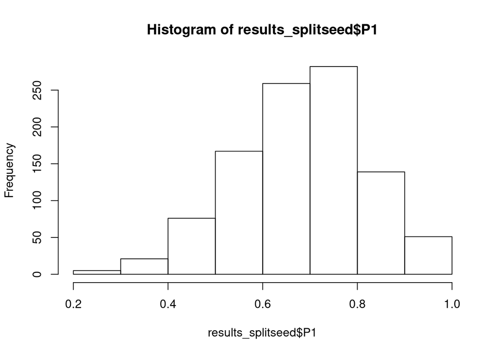

```r
hist(results_splitseed$P1, breaks = 10)
```

```r
which.max(results_splitseed$P1)
```

```
## [1] 66
```

```r
sum(results_splitseed$P1 >= results_splitseed$P1[1]) -1
```

```
## [1] NA
```

```r
# results_splitseed$P1[(results_splitseed$P1 >= results_splitseed$P1[1])]
sum(results_splitseed$P1 == 1)
```

```
## [1] NA
```

```r
sum(results_splitseed$`prob ratio 1` < 1)
```

```
## [1] NA
```

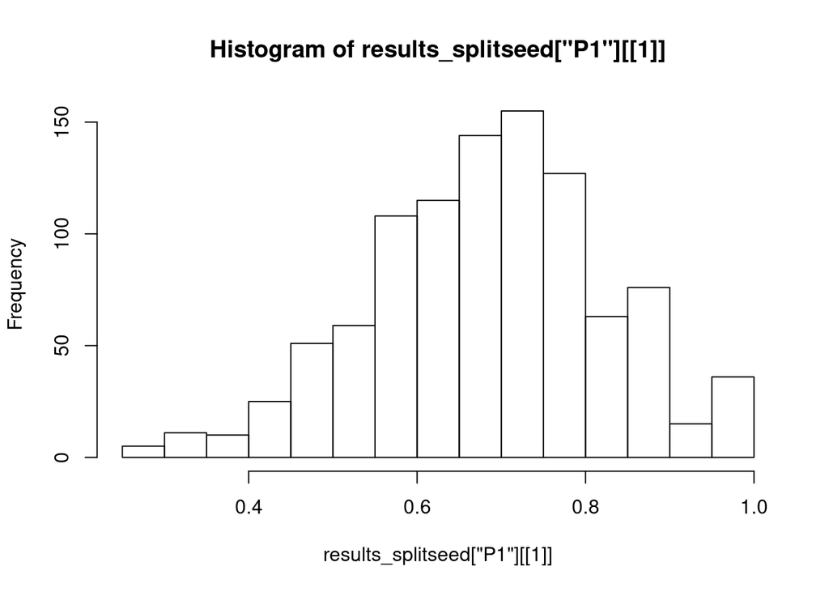

```r
hist( results_splitseed['P1'][[1]])
```

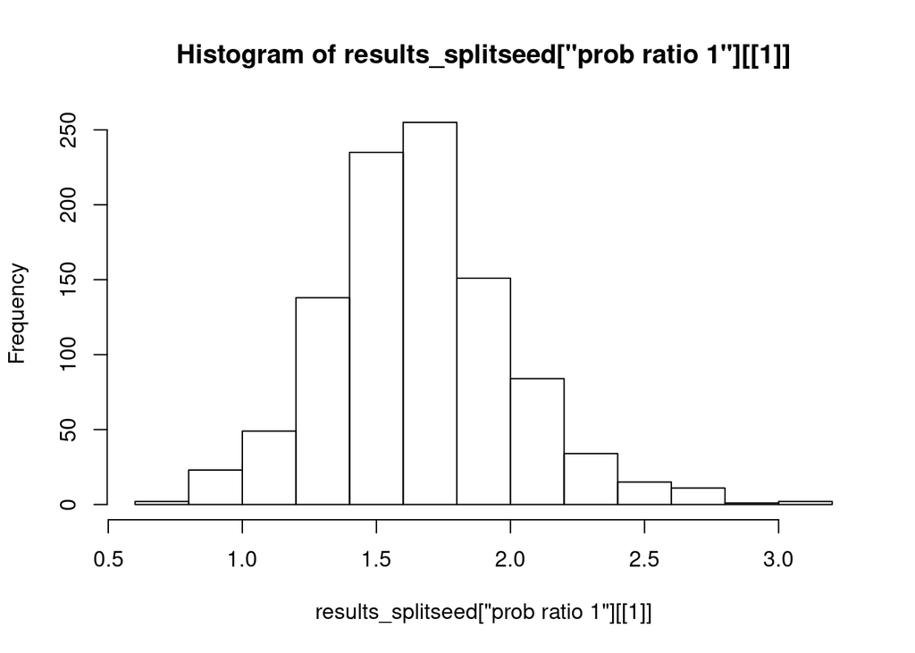

```r
hist( results_splitseed['prob ratio 1'][[1]])
```